# Exercise Lesson 7

Janna & Stefan

Wednesday, January 14, 2015

This is our result of the exercise of Lesson 7

First we load the libraries:

```r
library(raster)
```

Next we load the data from the data folder:

```r
load("data/GewataB1.rda")
load("data/GewataB2.rda")
load("data/GewataB3.rda")
load("data/GewataB4.rda")
load("data/GewataB5.rda")
load("data/GewataB7.rda")
load("data/vcfGewata.rda")
```

Then we remove the unrealistic values from the vcf file (which contains tree cover):

```r
vcfGewata[vcfGewata > 100] <- NA
```

After that we put the bands together in a brick…

```r
gewata <- brick(GewataB1, GewataB2, GewataB3, GewataB4, GewataB5, GewataB7, vcfGewata)
gewata_novcf <- brick(GewataB1, GewataB2, GewataB3, GewataB4, GewataB5, GewataB7)
```

… and we plot the bands in pairs to show correlations:

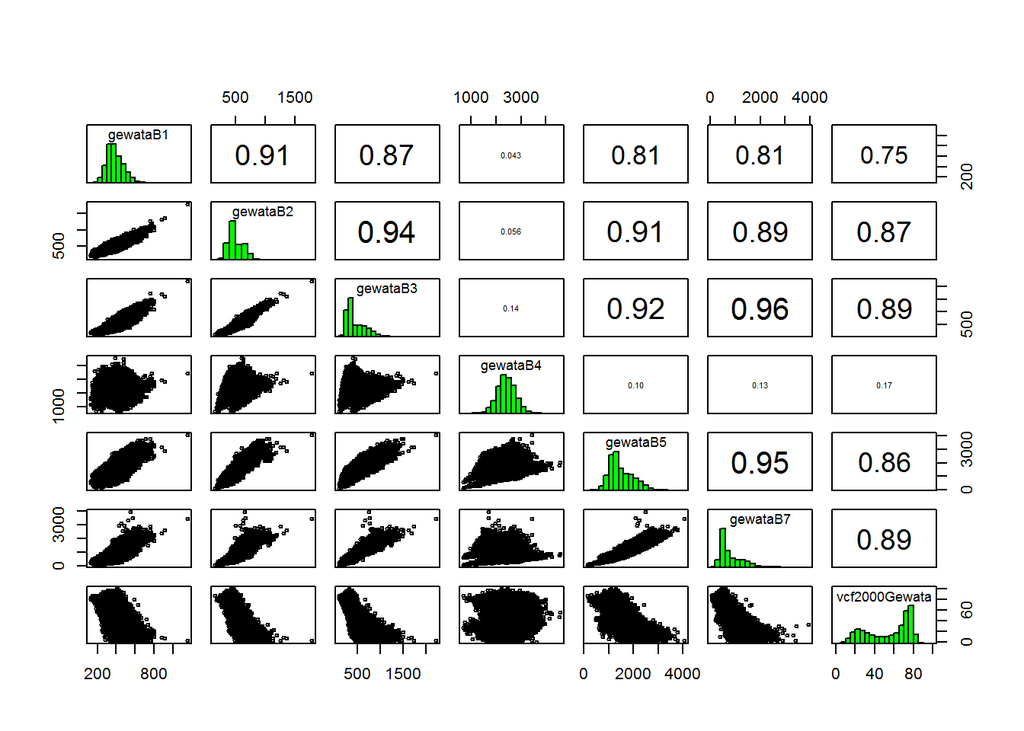

```r
pairs(gewata)
```

Now we choose the bands with the highest correlation and we plot them seperately:

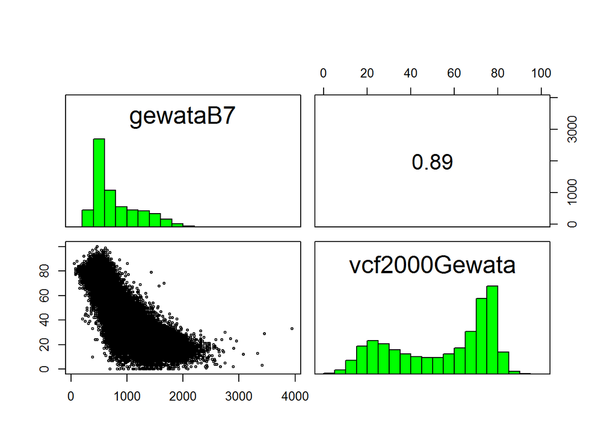

```r
pairs(brick(GewataB7, vcfGewata))
```

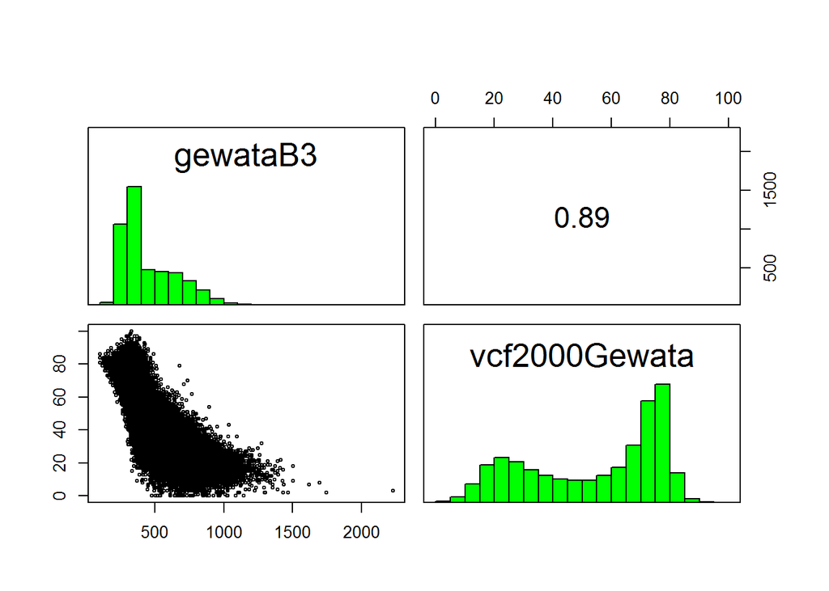

```r
pairs(brick(GewataB3, vcfGewata))
```

Now we create the linear model, which predicts the VCF with the reflections of the different bands. In the summary a column named ‘Pr(>|t|)’ is given. Small values mean that the probability that this correlation results from coincidence is really small, so the bands with the small p-values are important: these are all the bands except for band 7.

```r
valuetable <- as.data.frame(getValues(gewata))
modelLM <- lm(formula = vcf2000Gewata ~ gewataB1 + gewataB2 + gewataB3 + gewataB4 + gewataB5 + gewataB7, data = valuetable)
summary(modelLM)
```

```
##
## Call:
## lm(formula = vcf2000Gewata ~ gewataB1 + gewataB2 + gewataB3 +
##     gewataB4 + gewataB5 + gewataB7, data = valuetable)
##
## Residuals:
##     Min      1Q  Median      3Q     Max
## -58.205  -4.636   0.715   5.211 258.436
##
## Coefficients:
##               Estimate Std. Error  t value Pr(>|t|)
## (Intercept)  8.549e+01  5.723e-02 1493.805   <2e-16 ***
## gewataB1     9.291e-02  1.889e-04  491.817   <2e-16 ***
## gewataB2    -1.505e-01  2.353e-04 -639.622   <2e-16 ***
## gewataB3    -2.528e-03  1.698e-04  -14.889   <2e-16 ***
## gewataB4     1.661e-02  2.790e-05  595.378   <2e-16 ***
## gewataB5    -2.006e-02  7.036e-05 -285.119   <2e-16 ***
## gewataB7     2.549e-05  8.969e-05    0.284    0.776
## ---
## Signif. codes:  0 '***' 0.001 '**' 0.01 '*' 0.05 '.' 0.1 ' ' 1
##
## Residual standard error: 8.606 on 1808277 degrees of freedom
##   (13712 observations deleted due to missingness)
## Multiple R-squared:  0.8582, Adjusted R-squared:  0.8582
## F-statistic: 1.824e+06 on 6 and 1808277 DF,  p-value: < 2.2e-16
```

Now we make the predicted tree cover raster and plot it:

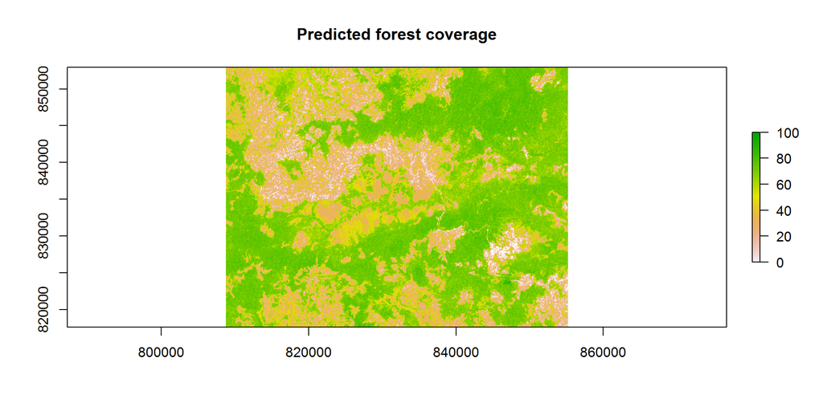

```r
predLC <- predict(gewata_novcf, model=modelLM, na.rm=TRUE)
predLC[predLC < 0] <- NA

plot(predLC, main="Predicted forest coverage", zlim=c(0,100))
```

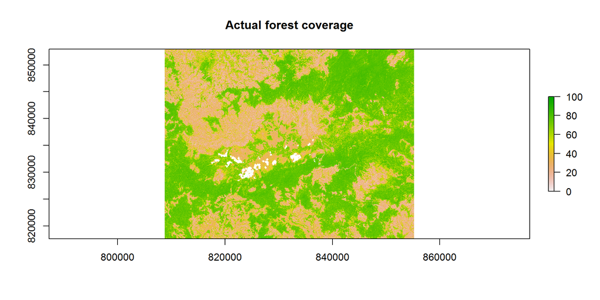

```r
plot(gewata$vcf2000Gewata, main="Actual forest coverage", zlim=c(0,100))
```

Then we calculate the RMSE by using rasterlayers:

```r
sqdif <- (gewata$vcf2000Gewata-predLC)^2
sqdifdf <- as.data.frame(sqdif)
RMSE_rasterlayer<-sqrt(mean(sqdifdf$layer, na.rm=TRUE))
RMSE_rasterlayer
```

```
## [1] 8.356825
```

It is also possible to calculate the RMSE by doing the following:

```r
RMSE_cellstats <- sqrt(cellStats(((gewata$vcf2000Gewata-predLC)^2), stat='mean'))
RMSE_cellstats
```

```
## [1] 8.356825
```

The last part is to calculate the difference between the actual and predicted tree coverage per class

```r
differenceTC<-(gewata$vcf2000Gewata-predLC)^2

load("data/trainingPoly.rda")
trainingPoly@data$Code <- as.numeric(trainingPoly@data$Class)
ndvi <- overlay(GewataB4, GewataB3, fun=function(x,y){(x-y)/(x+y)})
classes <- rasterize(trainingPoly, ndvi, field='Code')

averagediff<-zonal(differenceTC, classes)
RMSEClasses<-sqrt(averagediff[,2])
RMSEClasses
```

```
## [1]  8.865262  4.987001 11.913414
```

This results in an RMSE=8.87 for cropland, an RMSE=4.99 for forest and an RMSE=11.91 for wetland. This means that the difference between the predicted and actual tree cover is the biggest for wetland.